# Practical Machine Learning: week 4 course project

Benoît Fayolle

24 janvier 2018

### Synopsis

6 participants are asked to perform a weight lifting exercise: the Unilateral Dumbbell Biceps Curl. Each participant has 4 acceleration sensors on different part of his body and one on the dumbbell. They are asked to perform five variations over the exercise. Only one of them being the correct way. In this document, we load the data recorded during this experience, analyze it and construct a machine learning algorithm to predict “how well” the exercise is done.

### Loading & Cleaning

```r
training<-read.csv("pml-training.csv",sep=",")
testing<-read.csv("pml-testing.csv",sep=",")
```

It is easy to verify that the variable raw_timestamp_part_1 is the number of seconds since 1970-01-01 and the variable raw_timestamp_part_2 is the division of this second. A variable timestamp is created by agregating the two parts and substracting the first value for readability. The absolute value of time is not important in the phenomenon we are analysing

```r
as.POSIXlt(training$raw_timestamp_part_1,"%S",origin="1970-01-01 00:00:00")[1:3]
```

```
## [1] "2011-12-05 11:23:51" "2011-12-05 11:23:51" "2011-12-05 11:23:51"
```

```r
head(training$cvtd_timestamp,3)
```

```
## [1] 05/12/2011 11:23 05/12/2011 11:23 05/12/2011 11:23
## 20 Levels: 02/12/2011 13:32 02/12/2011 13:33 ... 30/11/2011 17:12
```

```r
training$timestamp<-training$raw_timestamp_part_1+training$raw_timestamp_part_2/1e6
training$timestamp<-training$timestamp-training$timestamp[1]
testing$timestamp<-testing$raw_timestamp_part_1+testing$raw_timestamp_part_2/1e6
testing$timestamp<-testing$timestamp-testing$timestamp[1]
str(training[,1:15])
```

```
## 'data.frame':    19622 obs. of  15 variables:
##  $ X                   : int  1 2 3 4 5 6 7 8 9 10 ...
##  $ user_name           : Factor w/ 6 levels "adelmo","carlitos",..: 2 2 2 2 2 2 2 2 2 2 ...
##  $ raw_timestamp_part_1: int  1323084231 1323084231 1323084231 1323084232 1323084232 1323084232 1323084232 1323084232 1323084232 1323084232 ...
##  $ raw_timestamp_part_2: int  788290 808298 820366 120339 196328 304277 368296 440390 484323 484434 ...
##  $ cvtd_timestamp      : Factor w/ 20 levels "02/12/2011 13:32",..: 9 9 9 9 9 9 9 9 9 9 ...
##  $ new_window          : Factor w/ 2 levels "no","yes": 1 1 1 1 1 1 1 1 1 1 ...
##  $ num_window          : int  11 11 11 12 12 12 12 12 12 12 ...
##  $ roll_belt           : num  1.41 1.41 1.42 1.48 1.48 1.45 1.42 1.42 1.43 1.45 ...
##  $ pitch_belt          : num  8.07 8.07 8.07 8.05 8.07 8.06 8.09 8.13 8.16 8.17 ...
##  $ yaw_belt            : num  -94.4 -94.4 -94.4 -94.4 -94.4 -94.4 -94.4 -94.4 -94.4 -94.4 ...
##  $ total_accel_belt    : int  3 3 3 3 3 3 3 3 3 3 ...
##  $ kurtosis_roll_belt  : Factor w/ 397 levels "","-0.016850",..: 1 1 1 1 1 1 1 1 1 1 ...
##  $ kurtosis_picth_belt : Factor w/ 317 levels "","-0.021887",..: 1 1 1 1 1 1 1 1 1 1 ...
##  $ kurtosis_yaw_belt   : Factor w/ 2 levels "","#DIV/0!": 1 1 1 1 1 1 1 1 1 1 ...
##  $ skewness_roll_belt  : Factor w/ 395 levels "","-0.003095",..: 1 1 1 1 1 1 1 1 1 1 ...
```

As one can see, some numeric/continuous variables have been processed as factors by the read.csv() function. kurtosis_roll_belt is the first example. It is necessary to transform them back to their true numeric value to make a correct inference.

```r
iNumeric<-grep("kurtosis|skewness|max|min|amplitude|total",names(training))
for (i in iNumeric){
        if(class(training[,i])=="factor"){
                training[,i]<-suppressWarnings(as.numeric(as.character(training[,i])))
                testing[,i]<-suppressWarnings(as.numeric(as.character(testing[,i])))
        }
}
```

a lot of variables in the dataset have almost only NA values

```r
table(apply(training,2,function(x){length(which(is.na(x)))}))
```

```
##
##     0 19216 19217 19218 19220 19221 19225 19226 19227 19248 19293 19294
##    61    67     1     1     1     4     1     4     2     2     1     1
## 19296 19299 19300 19301 19622
##     2     1     4     2     6
```

The training dataset having 19622 observations, all the variables having 19216 or more NA values are removed from the analysis:

```r
iNA<-which(apply(training,2,function(x){length(which(is.na(x)))})>=19216)
training<-training[,-iNA];testing<-testing[,-iNA]
```

Also dropping:

- the X variable which is just a index variable
- other timestamps
- new window and num_window which are not physical variable records

```r
library(dplyr)
training<-select(training,-X,-raw_timestamp_part_1,-raw_timestamp_part_2,-cvtd_timestamp,
-new_window,-num_window)
testing<-select(testing,-X,-raw_timestamp_part_1,-raw_timestamp_part_2,-cvtd_timestamp,
-new_window,-num_window)
```

### Structure of the dataset

The data provided are multiple time series. Even though the weight lifting exercises are typically periodic if they are correctly executed, the periods can vary over time, person and exercise. Let’s see how the data breaks down in regards to *user_name* and *classe* variable.

```r
library(ggplot2)
training$userExercise<-factor(paste(training$user_name,training$classe,sep="_"))
table(training$userExercise)
```

```
##
##   adelmo_A   adelmo_B   adelmo_C   adelmo_D   adelmo_E carlitos_A
##       1165        776        750        515        686        834
## carlitos_B carlitos_C carlitos_D carlitos_E  charles_A  charles_B
##        690        493        486        609        899        745
##  charles_C  charles_D  charles_E   eurico_A   eurico_B   eurico_C
##        539        642        711        865        592        489
##   eurico_D   eurico_E   jeremy_A   jeremy_B   jeremy_C   jeremy_D
##        582        542       1177        489        652        522
##   jeremy_E    pedro_A    pedro_B    pedro_C    pedro_D    pedro_E
##        562        640        505        499        469        497
```

```r
mean(table(training$userExercise))
```

```
## [1] 654.0667
```

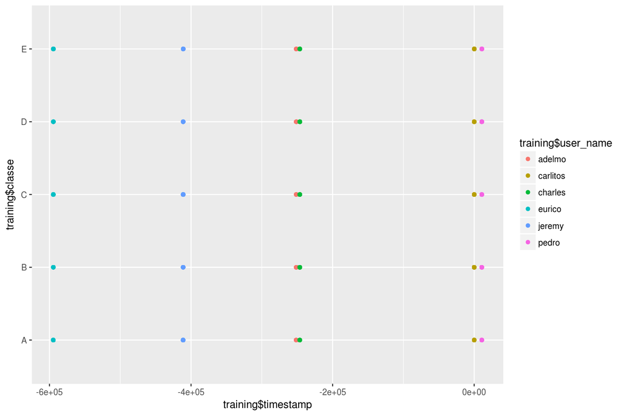

```r
training<-training[order(training$timestamp),]
qplot(training$timestamp,training$classe,col=training$user_name)
```

As it can be seen in the graphic above, each participant performed the exercises consecutively. Each exercise for each person was recorded with an average 654 sample for each variable. The 5 classes are relatively well balanced.

### Data slicing

Since we are trying to predict a lifting exercise, the signal recorded is a time series that involves periodic phenomena. We could think this require a proper data slicing in chunks since the value of each sample depends on its neighbour. But looking at the testset provided, it would be unnecessary. The testset is composed of just 20 uncorrelated single samples. We slice the training data into subtraining and subtesting datasets with the createDataPartition function. To ensure balanced classe in those sub datasets, we use a custom factor we call *userExercise*

```r
library(caret);library(dplyr)
### sub train/test datasets creation
trainTemp<-{}
testTemp<-{}
for (i in levels(training$userExercise)){ ##loop over the combination of user/classe
        subtraining<-subset(training,userExercise==i)
        inTrain<-createDataPartition(y=subtraining$timestamp,p=0.8)$Resample1
        trainTemp<-rbind(trainTemp,subtraining[inTrain,]) #reconstruct subtrain dataset
        testTemp<-rbind(testTemp,subtraining[-inTrain,])
}
trainTemp<-select(trainTemp,-userExercise,-timestamp,-user_name)
testTemp<-select(testTemp,-userExercise,-timestamp,-user_name)
###update factors
trainTemp<-droplevels(trainTemp);testTemp<-droplevels(testTemp)
```

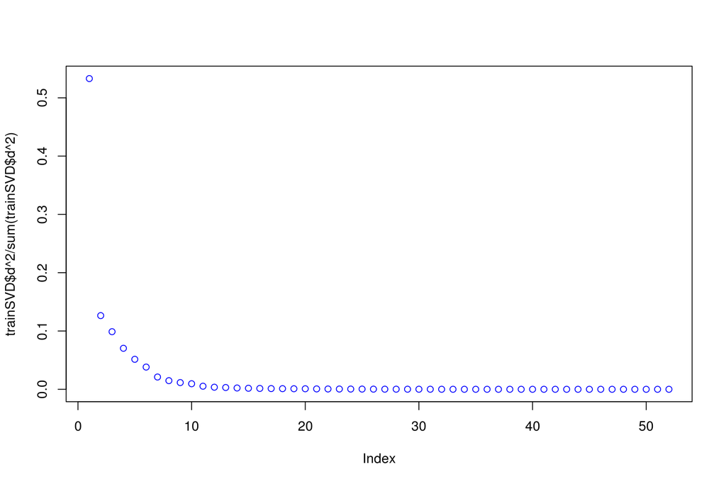

```r
###svd and variance explained
trainSVD<-svd(select(trainTemp,-classe))
plot(trainSVD$d^2/sum(trainSVD$d^2),col="blue")
```

```r
head(trainSVD$d^2/sum(trainSVD$d^2),12)
```

```
##  [1] 0.532969527 0.126385470 0.098797374 0.070347663 0.051435948
##  [6] 0.038110044 0.021049807 0.014805318 0.011515254 0.009515837
## [11] 0.005287494 0.003590498
```

- CART model: simple classification tree with the ‘rpart’ caret version
- random forest : much more efficient model but compute-intensive

```r
###precprocessing with PCA
preObj<-preProcess(select(trainTemp,-classe),method="pca",pcaComp = 11)
preTrain<-predict(preObj,trainTemp);preTest<-predict(preObj,testTemp)

### CART
mod1<-train(classe~.,data=preTrain,method="rpart")
print(confusionMatrix(mod1));print(mod1$finalModel);
```

```
## Bootstrapped (25 reps) Confusion Matrix
##
## (entries are percentual average cell counts across resamples)
##
##           Reference
## Prediction    A    B    C    D    E
##          A 21.4  7.8 10.8  5.2  7.1
##          B  0.1  1.1  0.1  0.4  0.5
##          C  0.0  0.0  0.0  0.0  0.0
##          D  1.4  2.4  0.7  4.3  1.7
##          E  5.6  7.9  5.8  6.5  9.1
##
##  Accuracy (average) : 0.3588
```

```
## n= 15743
##
## node), split, n, loss, yval, (yprob)
##       * denotes terminal node
##
## 1) root 15743 11271 A (0.28 0.19 0.17 0.16 0.18)
##   2) PC8< 1.275671 12829  8694 A (0.32 0.17 0.2 0.12 0.19)
##     4) PC3>=-0.3449636 7824  4499 A (0.42 0.14 0.22 0.083 0.13) *
##     5) PC3< -0.3449636 5005  3665 E (0.16 0.22 0.18 0.17 0.27) *
##   3) PC8>=1.275671 2914  1827 D (0.12 0.28 0.059 0.37 0.17) *
```

```r
pred1<-predict(mod1,preTest)
print(confusionMatrix(pred1,reference=preTest$classe))
```

```
## Confusion Matrix and Statistics
##
##           Reference
## Prediction   A   B   C   D   E
##          A 849 255 425 165 278
##          B   0   0   0   0   0
##          C   0   0   0   0   0
##          D  78 179  44 269 120
##          E 181 314 205 202 315
##
## Overall Statistics
##
##                Accuracy : 0.3694
##                  95% CI : (0.3542, 0.3848)
##     No Information Rate : 0.2856
##     P-Value [Acc > NIR] : < 2.2e-16
##
##                   Kappa : 0.1789
##  Mcnemar's Test P-Value : NA
##
## Statistics by Class:
##
##                      Class: A Class: B Class: C Class: D Class: E
## Sensitivity            0.7662   0.0000   0.0000  0.42296  0.44180
## Specificity            0.5947   1.0000   1.0000  0.87018  0.71510
## Pos Pred Value         0.4305      NaN      NaN  0.38986  0.25883
## Neg Pred Value         0.8642   0.8072   0.8262  0.88492  0.85049
## Prevalence             0.2856   0.1928   0.1738  0.16396  0.18381
## Detection Rate         0.2189   0.0000   0.0000  0.06935  0.08121
## Detection Prevalence   0.5084   0.0000   0.0000  0.17788  0.31374
## Balanced Accuracy      0.6805   0.5000   0.5000  0.64657  0.57845
```

```r
### RF with 5 resamples
trainControlObj<-trainControl(number=5,method="cv",seeds=NA,allowParallel=T)
mod2<-train(classe~.,data=preTrain,method="rf",trainControl=trainControlObj,
            verboseIter=T)
print(confusionMatrix(mod2));print(mod2$finalModel)
```

```
## Bootstrapped (25 reps) Confusion Matrix
##
## (entries are percentual average cell counts across resamples)
##
##           Reference
## Prediction    A    B    C    D    E
##          A 27.3  0.6  0.3  0.2  0.1
##          B  0.3 18.0  0.4  0.1  0.2
##          C  0.4  0.7 16.5  0.9  0.2
##          D  0.2  0.1  0.3 15.0  0.2
##          E  0.1  0.1  0.1  0.1 17.6
##
##  Accuracy (average) : 0.9437
```

```
##
## Call:
##  randomForest(x = x, y = y, mtry = param$mtry, trainControl = ..1,      verboseIter = ..2)
##                Type of random forest: classification
##                      Number of trees: 500
## No. of variables tried at each split: 2
##
##         OOB estimate of  error rate: 3.77%
## Confusion matrix:
##      A    B    C    D    E class.error
## A 4377   25   45   18    7  0.02124329
## B   73 2885   72   11    8  0.05378813
## C   26   37 2641   38    6  0.03893741
## D   23    8  126 2417    6  0.06317829
## E    6   20   19   19 2830  0.02211472
```

```r
pred2<-predict(mod2,preTest)
#out of sample error
print(confusionMatrix(pred2,reference=preTest$classe))
```

```
## Confusion Matrix and Statistics
##
##           Reference
## Prediction    A    B    C    D    E
##          A 1085   13    5    2    3
##          B    7  718    8    1    3
##          C   10    7  654   29    8
##          D    5    6    4  598    4
##          E    1    4    3    6  695
##
## Overall Statistics
##
##                Accuracy : 0.9667
##                  95% CI : (0.9606, 0.9722)
##     No Information Rate : 0.2856
##     P-Value [Acc > NIR] : < 2.2e-16
##
##                   Kappa : 0.9579
##  Mcnemar's Test P-Value : 0.0005551
##
## Statistics by Class:
##
##                      Class: A Class: B Class: C Class: D Class: E
## Sensitivity            0.9792   0.9599   0.9703   0.9403   0.9748
## Specificity            0.9917   0.9939   0.9832   0.9941   0.9956
## Pos Pred Value         0.9792   0.9742   0.9237   0.9692   0.9803
## Neg Pred Value         0.9917   0.9905   0.9937   0.9884   0.9943
## Prevalence             0.2856   0.1928   0.1738   0.1640   0.1838
## Detection Rate         0.2797   0.1851   0.1686   0.1542   0.1792
## Detection Prevalence   0.2856   0.1900   0.1825   0.1591   0.1828
## Balanced Accuracy      0.9855   0.9769   0.9767   0.9672   0.9852
```

```r
### RF with 10 resamples
trainControlObj<-trainControl(number=10,method="cv",seeds=NA,allowParallel=T)
mod3<-train(classe~.,data=preTrain,method="rf",trainControl=trainControlObj,
            verboseIter=T)
print(confusionMatrix(mod3));print(mod3$finalModel)
```

```
## Bootstrapped (25 reps) Confusion Matrix
##
## (entries are percentual average cell counts across resamples)
##
##           Reference
## Prediction    A    B    C    D    E
##          A 27.3  0.6  0.3  0.2  0.1
##          B  0.2 17.9  0.4  0.1  0.2
##          C  0.4  0.6 16.5  0.9  0.2
##          D  0.2  0.1  0.3 15.2  0.2
##          E  0.1  0.1  0.1  0.1 17.6
##
##  Accuracy (average) : 0.9446
```

```
##
## Call:
##  randomForest(x = x, y = y, mtry = param$mtry, trainControl = ..1,      verboseIter = ..2)
##                Type of random forest: classification
##                      Number of trees: 500
## No. of variables tried at each split: 2
##
##         OOB estimate of  error rate: 3.81%
## Confusion matrix:
##      A    B    C    D    E class.error
## A 4375   24   48   18    7  0.02169052
## B   80 2885   65   12    7  0.05378813
## C   25   38 2642   35    8  0.03857351
## D   24   10  122 2416    8  0.06356589
## E    3   21   21   24 2825  0.02384243
```

```r
pred3<-predict(mod3,preTest)
#out of sample error
print(confusionMatrix(pred3,reference=preTest$classe))
```

```
## Confusion Matrix and Statistics
##
##           Reference
## Prediction    A    B    C    D    E
##          A 1083   13    5    2    2
##          B    7  720    9    1    5
##          C   10    7  652   29    8
##          D    7    4    4  600    4
##          E    1    4    4    4  694
##
## Overall Statistics
##
##                Accuracy : 0.9665
##                  95% CI : (0.9603, 0.9719)
##     No Information Rate : 0.2856
##     P-Value [Acc > NIR] : < 2.2e-16
##
##                   Kappa : 0.9576
##  Mcnemar's Test P-Value : 0.001241
##
## Statistics by Class:
##
##                      Class: A Class: B Class: C Class: D Class: E
## Sensitivity            0.9774   0.9626   0.9674   0.9434   0.9734
## Specificity            0.9921   0.9930   0.9832   0.9941   0.9959
## Pos Pred Value         0.9801   0.9704   0.9235   0.9693   0.9816
## Neg Pred Value         0.9910   0.9911   0.9931   0.9890   0.9940
## Prevalence             0.2856   0.1928   0.1738   0.1640   0.1838
## Detection Rate         0.2792   0.1856   0.1681   0.1547   0.1789
## Detection Prevalence   0.2849   0.1913   0.1820   0.1596   0.1823
## Balanced Accuracy      0.9847   0.9778   0.9753   0.9688   0.9846
```

### Out of sample error

Since we have multiple balanced classes, we use the accuracy to evaluate the out of sample error of our classification problem:

```r
testingPCA<-predict(preObj,select(testing,-user_name,-timestamp))#preprocessing
predFinal<-predict(mod3,testingPCA)
print(predFinal)
```

```
##  [1] B A A A A E D B A A A C B A E E A B B B
## Levels: A B C D E
```